# Data types II: dataframes, lists, and other data types

A. Kaliontzopoulou, A. Jesús Muñoz-Pajares, P. Tarroso, U. Enriquez-Urzelai

4-8 November 2019

## **Content Description**

You can find here a small introduction to dataframes, lists, and other data types and all code found in today’s lecture. At the end, you have some practice “challenges” to try to solve. The solution is then provided.

## **Introduction**

From the previous lecture we already know that R allows different types of data and that we may build collections with data like vectors matrices and arrays. However, these data collections we learn so far only accept elements of the same time.

Most of our databases have mixed data types: numbers, words (strings), categorical data (factors). How can you deal with that in R?

R programming language makes a distinction between objects that are ATOMIC (object of the same mode, like vector) and those that are RECURSIVE (that might contain multiple modes).

We will look first to data.frames, than we will see lists and at the end some special data structures (and data.frames again!).

## **Framing dataframes**

Dataframes are table-like structures that can hold different types of data. They allow access to data in similar ways as matrices.

```r
?data.frame
```

There are multiple ways to build a dataframe. Let’s start by a set of separate vectors with different types:

```r
vec1 <- c(1, 2, 3, 4, 5)
vec3 <- rnorm(5)
vec5 <- c("male", "male", "female", "female", "female")

df1 <- data.frame(vec1, vec3, vec5)
df1
```

```
##   vec1       vec3   vec5
## 1    1 -1.5008081   male
## 2    2 -0.2947031   male
## 3    3  0.4756556 female
## 4    4  1.1769461 female
## 5    5 -1.7867841 female
```

We could also use a matrix:

```r
mat <- matrix(1:16, nrow=4, byrow=T)
df2 <- as.data.frame(mat)
df2
```

```
##   V1 V2 V3 V4
## 1  1  2  3  4
## 2  5  6  7  8
## 3  9 10 11 12
## 4 13 14 15 16
```

However, if all our data is numeric, it would be better to keep it as a matrix.

Notice that on ‘df1’ above, the columns inherited the names of the vectors and on ‘df2’ we got *V(number)* names.

We easily change column and row names of a dataframe.

```r
colnames(df1) <- c("var1", "var2", "var3")
df1
```

```
##   var1       var2   var3
## 1    1 -1.5008081   male
## 2    2 -0.2947031   male
## 3    3  0.4756556 female
## 4    4  1.1769461 female
## 5    5 -1.7867841 female
```

Be careful because names are strings: if you provide a numeric value to column names it will be coerced to character type and may be the source of many errors (more in the indexing class).

We can also name columns directly when building a dataframe:

```r
df1 <- data.frame(ID=vec1, value=vec3, sex=vec5)
df1
```

```
##   ID      value    sex
## 1  1 -1.5008081   male
## 2  2 -0.2947031   male
## 3  3  0.4756556 female
## 4  4  1.1769461 female
## 5  5 -1.7867841 female
```

### $\color{red}{\text{CHALLENGE}}$

```r
rownames(df1) <- c("CB232", "CB321", "CB112", "CB432", "CB112")
```

```
## Error in `.rowNamesDF<-`(x, value = value): duplicate 'row.names' are not allowed
```

1. Why does it throw an error?
2. Give a sequence of names like “Sample_1”, “Sample_2” to dataframe rows.

One useful propriety of the dataframes (similarly to matrices) is that we can access particular rows and columns of data. Here are different ways to access data:

```r
df1[1,]
```

```
##   ID     value  sex
## 1  1 -1.500808 male
```

```r
df1[,3]
```

```
## [1] male   male   female female female
## Levels: female male
```

```r
df1$ID
```

```
## [1] 1 2 3 4 5
```

```r
df1[,"ID"]
```

```
## [1] 1 2 3 4 5
```

Indexing columns and rows is a very powerful tool in R. We will more of that tomorrow.

### $\color{red}{\text{CHALLENGE}}$

```r
df1[,"F1"]
```

```
## Error in `[.data.frame`(df1, , "F1"): undefined columns selected
```

3. What does the error mean?

We can grow an existent dataframe with simple functions. We can add more columns as long as the new column has the same number of samples or new rows, as long as has the same number of columns:

```r
altitude <- c(320, 523, 156, 299, 432)
df2 <- cbind(df1, altitude)

newsample <- c(6, -0.32, "male", 222)
df2 <- rbind(df2, newsample)
df2
```

```
##   ID             value    sex altitude
## 1  1 -1.50080806425188   male      320
## 2  2 -0.29470313117228   male      523
## 3  3 0.475655602764592 female      156
## 4  4  1.17694607954727 female      299
## 5  5 -1.78678410548375 female      432
## 6  6             -0.32   male      222
```

We can also use the dataframes proprieties as before to add new columns or rows:

```r
f1 <- as.factor(c(rep("A", 3), rep("B", 2)))
df1[,4] <- f1
df1
```

```
##   ID      value    sex V4
## 1  1 -1.5008081   male  A
## 2  2 -0.2947031   male  A
## 3  3  0.4756556 female  A
## 4  4  1.1769461 female  B
## 5  5 -1.7867841 female  B
```

```r
df1$f1 <- f1
df1
```

```
##   ID      value    sex V4 f1
## 1  1 -1.5008081   male  A  A
## 2  2 -0.2947031   male  A  A
## 3  3  0.4756556 female  A  A
## 4  4  1.1769461 female  B  B
## 5  5 -1.7867841 female  B  B
```

### $\color{red}{\text{CHALLENGE}}$

```r
df1[,"F1"]
```

```
## Error in `[.data.frame`(df1, , "F1"): undefined columns selected
```

4. We still have an error with the code above. Why?
5. There is a problem with the result of rbind above. Can you spot it? (hint: check the dataframe variables).

Some basic functions to check dataframe proprieties:

```r
class(df1)
dim(df1)
ncol(df1)
nrow(df1)
dimnames(df1)
colnames(df1)
str(df1)
```

We might want to calculate with data in the dataframe. There are several functions to do basic calculations, but the results might not be as expected.

```r
apply(df1, 2, mean)
```

```
##    ID value   sex    V4    f1
##    NA    NA    NA    NA    NA
```

Notice that it returns only NAs because we have mixed data types. This error shows that you should avoid using apply function in data.frames. This family of functions is useful with matrices and arrays which are ATOMIC check *as.matrix(df1)* (you can also check *lapply(df1, mean)* and wait to the end of the session to know why!).

We can extract numeric columns as a dataframe and proceed with calculations.

```r
df3 <- cbind(df1$ID, df1$value)
apply(df3, 2, mean)
```

```
## [1]  3.0000000 -0.3859387
```

```r
rowMeans(df3)
```

```
## [1] -0.2504040  0.8526484  1.7378278  2.5884730  1.6066079
```

```r
colMeans(df3)
```

```
## [1]  3.0000000 -0.3859387
```

```r
rowSums(df3)
```

```
## [1] -0.5008081  1.7052969  3.4756556  5.1769461  3.2132159
```

```r
colSums(df3)
```

```
## [1] 15.000000 -1.929694
```

```r
colSums(df3)/nrow(df3)
```

```
## [1]  3.0000000 -0.3859387
```

### $\color{red}{\text{CHALLENGE}}$

6. Create a dataframe with 100 rows and three columns: first numeric, second text and third factor. Use random generation to populate the dataframe.
7. Get the mean of the columns where is possible to calculate a value.

Creating dataframes from scratch isn’t a very common task. The most common way to create a dataframe is to import data from a file or data base (next lecture).

## Lists

Lists are **recursive** objects: can hold any type of data including their own type. They are a basal object in most complex R code but seldom used in common scripts.

```r
?list
```

So let’s start creating a list

```r
myemptylist <- list()
myemptylist
```

```
## list()
```

we can also create lists with some data. In the following example we create a list holding different data types:

```r
my.list1 <- list(vec1, vec3, 23, "this is a list")
my.list1
```

```
## [[1]]
## [1] 1 2 3 4 5
##
## [[2]]
## [1] -1.5008081 -0.2947031  0.4756556  1.1769461 -1.7867841
##
## [[3]]
## [1] 23
##
## [[4]]
## [1] "this is a list"
```

Notice that the way R displays data in list is different than what we saw before. Elements in lists are ordered with *[[]]* and inside each element we have the data we created with the associated data type.

### $\color{red}{\text{CHALLENGE}}$

```r
my.list2 <- list(item1=vec1, item2=vec3, item3=23, item4="this is a list")
```

8. What is the difference between this list and *my.list1*?

We can increase the complexity of the elements in the list with matrices and arrays.

```r
my.matrix <- matrix(rnorm(20), 10)

my.array <- array(1:20, dim=c(5, 2, 2))

my.list3 <- list(item1=vec1, item2=vec3, my.matrix=my.matrix,
                 the.array=my.array, DF=df1)
my.list3
```

```
## $item1
## [1] 1 2 3 4 5
##
## $item2
## [1] -1.5008081 -0.2947031  0.4756556  1.1769461 -1.7867841
##
## $my.matrix
##                [,1]        [,2]
##  [1,]  1.4855249514 -0.60407558
##  [2,] -1.5383367638 -1.21686462
##  [3,] -0.2390741155  0.23355478
##  [4,] -0.9659043722  0.59260654
##  [5,]  0.4613021256  0.76326299
##  [6,]  1.1422537589  1.56980157
##  [7,]  0.0509791063 -0.77730953
##  [8,] -0.0311591169 -0.01425488
##  [9,] -0.0009719809  1.66752620
## [10,] -1.9473890655  0.89295225
##
## $the.array
## , , 1
##
##      [,1] [,2]
## [1,]    1    6
## [2,]    2    7
## [3,]    3    8
## [4,]    4    9
## [5,]    5   10
##
## , , 2
##
##      [,1] [,2]
## [1,]   11   16
## [2,]   12   17
## [3,]   13   18
## [4,]   14   19
## [5,]   15   20
##
##
## $DF
##   ID      value    sex V4 f1
## 1  1 -1.5008081   male  A  A
## 2  2 -0.2947031   male  A  A
## 3  3  0.4756556 female  A  A
## 4  4  1.1769461 female  B  B
## 5  5 -1.7867841 female  B  B
```

Functions used to inspect proprieties of other objects also work in lists. However notice that lists have length but do not have dimensions.

```r
dim(my.list3)
```

[output not shown]

```r
length(my.list3)
```

```
## [1] 5
```

```r
str(my.list3)
```

```
## List of 5
##  $ item1    : num [1:5] 1 2 3 4 5
##  $ item2    : num [1:5] -1.501 -0.295 0.476 1.177 -1.787
##  $ my.matrix: num [1:10, 1:2] 1.486 -1.538 -0.239 -0.966 0.461 ...
##  $ the.array: int [1:5, 1:2, 1:2] 1 2 3 4 5 6 7 8 9 10 ...
##  $ DF       :'data.frame':   5 obs. of  5 variables:
##   ..$ ID   : num [1:5] 1 2 3 4 5
##   ..$ value: num [1:5] -1.501 -0.295 0.476 1.177 -1.787
##   ..$ sex  : Factor w/ 2 levels "female","male": 2 2 1 1 1
##   ..$ V4   : Factor w/ 2 levels "A","B": 1 1 1 2 2
##   ..$ f1   : Factor w/ 2 levels "A","B": 1 1 1 2 2
```

```r
names(my.list3)
```

```
## [1] "item1"     "item2"     "my.matrix" "the.array" "DF"
```

Because lists can store all types of data, they have almost no restrictions to grow in size.

```r
my.list3$v10 <- vec1*10
my.list3$value <- df1$value*10
str(my.list3)
```

```
## List of 7
##  $ item1    : num [1:5] 1 2 3 4 5
##  $ item2    : num [1:5] -1.501 -0.295 0.476 1.177 -1.787
##  $ my.matrix: num [1:10, 1:2] 1.486 -1.538 -0.239 -0.966 0.461 ...
##  $ the.array: int [1:5, 1:2, 1:2] 1 2 3 4 5 6 7 8 9 10 ...
##  $ DF       :'data.frame':   5 obs. of  5 variables:
##   ..$ ID   : num [1:5] 1 2 3 4 5
##   ..$ value: num [1:5] -1.501 -0.295 0.476 1.177 -1.787
##   ..$ sex  : Factor w/ 2 levels "female","male": 2 2 1 1 1
##   ..$ V4   : Factor w/ 2 levels "A","B": 1 1 1 2 2
##   ..$ f1   : Factor w/ 2 levels "A","B": 1 1 1 2 2
##  $ v10      : num [1:5] 10 20 30 40 50
##  $ value    : num [1:5] -15.01 -2.95 4.76 11.77 -17.87
```

and similarly to dataframes we can assess elements in a list but using the double square bracket notation:

```r
my.list3$DF
```

```
##   ID      value    sex V4 f1
## 1  1 -1.5008081   male  A  A
## 2  2 -0.2947031   male  A  A
## 3  3  0.4756556 female  A  A
## 4  4  1.1769461 female  B  B
## 5  5 -1.7867841 female  B  B
```

```r
my.list3[["DF"]]
```

```
##   ID      value    sex V4 f1
## 1  1 -1.5008081   male  A  A
## 2  2 -0.2947031   male  A  A
## 3  3  0.4756556 female  A  A
## 4  4  1.1769461 female  B  B
## 5  5 -1.7867841 female  B  B
```

```r
my.list3[[5]]
```

```
##   ID      value    sex V4 f1
## 1  1 -1.5008081   male  A  A
## 2  2 -0.2947031   male  A  A
## 3  3  0.4756556 female  A  A
## 4  4  1.1769461 female  B  B
## 5  5 -1.7867841 female  B  B
```

### $\color{red}{\text{CHALLENGE}}$

9. Can you spot the difference between *my.list3[[5]]* and *my.list3[5]*?

As recursive object, a list can hold other lists in its structure.

```r
my.list3$list <- my.list2

my.list3$list
```

```
## $item1
## [1] 1 2 3 4 5
##
## $item2
## [1] -1.5008081 -0.2947031  0.4756556  1.1769461 -1.7867841
##
## $item3
## [1] 23
##
## $item4
## [1] "this is a list"
```

```r
my.list3$list$item4
```

```
## [1] "this is a list"
```

### $\color{red}{\text{CHALLENGE}}$

```r
my.list4 <- list(1:10, "1"=rnorm(25))
```

10. Try to get each element of the list with the list[[]] notation.

This illustrates the importance of not having numbers as element name.

As before, we can use *apply* family of functions to do calculations with each element in the list.

```r
lapply(my.list3, mean)
```

```
## $item1
## [1] 3
##
## $item2
## [1] -0.3859387
##
## $my.matrix
## [1] 0.07622121
##
## $the.array
## [1] 10.5
##
## $DF
## [1] NA
##
## $v10
## [1] 30
##
## $value
## [1] -3.859387
##
## $list
## [1] NA
```

### $\color{red}{\text{CHALLENGE}}$

11. Why the apply did not work in the data.frame and it works with the list with multiple data types?

## Other special data structures

Although data.frames are very tangled with R, being used in most scripts, are they an object of their own? We will see that, but first let’s have a look to what we are calling special objects.

Let’s create a simple vector with three elements:

```r
mypoints <- c(1, 2, 3)
names(mypoints) <- c("A", "B", "C")
```

As you see, these points can be represented in a line:

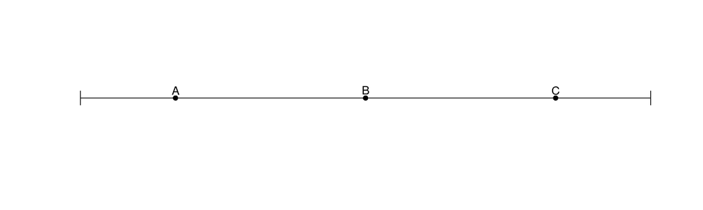

Let’s manually build a matrix of the Euclidean distance between these points:

```r
mydistMat <- matrix(c(0,1,2,1,0,1,2,1,0), 3, 3)
colnames(mydistMat) <- names(mypoints)
rownames(mydistMat) <- names(mypoints)
myDistMat
```

```
## Error in eval(expr, envir, enclos): object 'myDistMat' not found
```

1. The diagonal is ZERO
2. The matrix is symetric.

We can use an R function to build this distance matrix and have a special object:

```r
mydist <- dist(mypoints)
mydist
```

```
##   A B
## B 1
## C 2 1
```

Let’s check some of the proprieties of the newly created object:

```r
mode(mydist)
```

```
## [1] "numeric"
```

```r
typeof(mydist)
```

```
## [1] "double"
```

```r
class(mydist)
```

```
## [1] "dist"
```

This is showing us is that the only difference to the other objects (vector and matrix) is the class. The class is the propriety that makes different object behave differently:

- they have different ways to print their contents
- they might do a special plot
- they might be converted to other classes.

```r
as.matrix(mydist)
```

```
##   A B C
## A 0 1 2
## B 1 0 1
## C 2 1 0
```

How can I check what is really inside the ‘dist’ object? Classes have their own methods and attributes to process the kind of data they hold. We can have a look:

```r
str(mydist)
```

```
##  'dist' num [1:3] 1 2 1
##  - attr(*, "Size")= int 3
##  - attr(*, "Labels")= chr [1:3] "A" "B" "C"
##  - attr(*, "Diag")= logi FALSE
##  - attr(*, "Upper")= logi FALSE
##  - attr(*, "method")= chr "euclidean"
##  - attr(*, "call")= language dist(x = mypoints)
```

```r
attributes(mydist)
```

```
## $Size
## [1] 3
##
## $Labels
## [1] "A" "B" "C"
##
## $Diag
## [1] FALSE
##
## $Upper
## [1] FALSE
##
## $method
## [1] "euclidean"
##
## $call
## dist(x = mypoints)
##
## $class
## [1] "dist"
```

```r
mydist2 <- dist(mypoints, upper=TRUE)
attributes(mydist)
```

```
## $Size
## [1] 3
##
## $Labels
## [1] "A" "B" "C"
##
## $Diag
## [1] FALSE
##
## $Upper
## [1] FALSE
##
## $method
## [1] "euclidean"
##
## $call
## dist(x = mypoints)
##
## $class
## [1] "dist"
```

An important thing to keep in mind is that classes can be defined by the user. This means that new packages can have their own classes and their own methods to deal with specific data formats. Although it makes a little be more difficult to understand the code, the use of those classes became much more simple. We don’t really need to see what the code is, we just have to know what it does! For instance, let’s open a [tree](https://raw.githubusercontent.com/PhenoEvo/phenoevo.github.io/master/Intro2R/data/randomTree.tre) in R, using library ape:

```r
library(ape)
tree <- read.tree("randomTree.tre")
```

Now you would expect a list of things like nodes, tip names, values, etc or a text description of a tree like the Newick format…

```r
tree
```

```
##
## Phylogenetic tree with 100 tips and 99 internal nodes.
##
## Tip labels:
##  t81, t85, t1, t91, t28, t45, ...
##
## Rooted; includes branch lengths.
```

This means that tree has a dedicated class and that class has methods defined for showing what is inside.

```r
class(tree)
```

```
## [1] "phylo"
```

```r
mode(tree)
```

```
## [1] "list"
```

```r
typeof(tree)
```

```
## [1] "list"
```

```r
sumamry(tree)
```

```
## Error in sumamry(tree): could not find function "sumamry"
```

or a plot

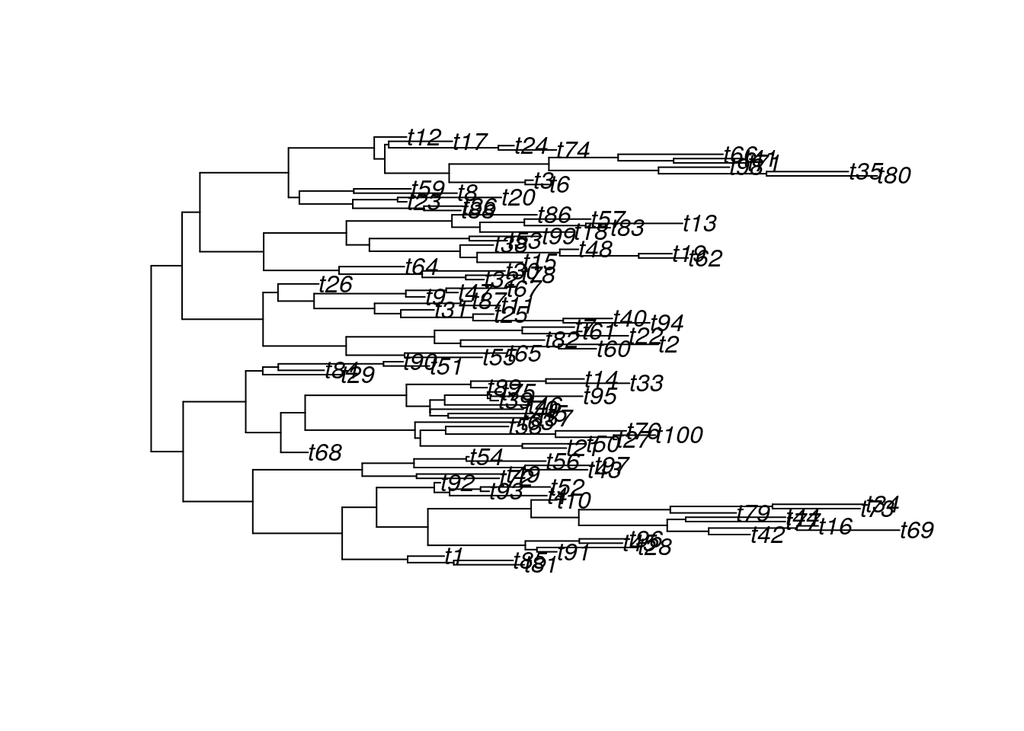

```r
plot(tree)
```

Another example is the use of spatial data in R. Here is an example with the raster package to read a raster from [file](https://raw.githubusercontent.com/PhenoEvo/phenoevo.github.io/master/Intro2R/data/dem.tif):

```r
library(raster)
rst <- raster("dem.tif")
rst
```

```
## class       : RasterLayer
## dimensions  : 200, 300, 60000  (nrow, ncol, ncell)
## resolution  : 0.1, 0.1  (x, y)
## extent      : -15.00042, 14.99958, 25.00042, 45.00042  (xmin, xmax, ymin, ymax)
## coord. ref. : +proj=longlat +datum=WGS84 +no_defs +ellps=WGS84 +towgs84=0,0,0
## data source : /home/pedro/Trabalho/Cursos/2019-20/IntoR/day2-02/Rmarkdown/dem.tif
## names       : dem
## values      : -32768, 32767  (min, max)
```

we can trust the package special methods to plot the data

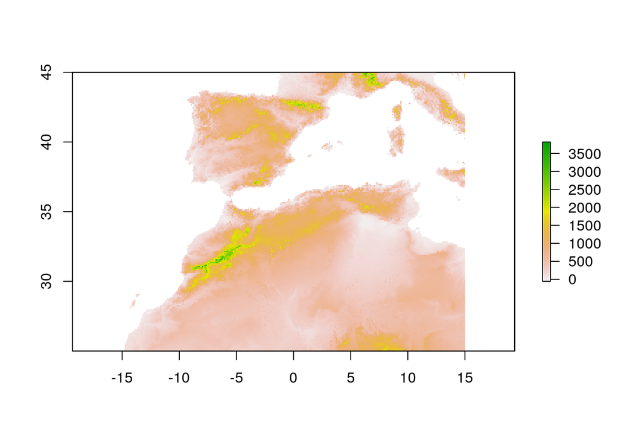

```r
plot(rst)
```

The class of an object is providing information to R to know what the object represents, which kind of data it holds and how to show it (plot, summary, etc).

### $\color{red}{\text{CHALLENGE}}$

```r
dt <- data.frame(a=1:10, b=11:20, c=21:30)
dt
```

```
##     a  b  c
## 1   1 11 21
## 2   2 12 22
## 3   3 13 23
## 4   4 14 24
## 5   5 15 25
## 6   6 16 26
## 7   7 17 27
## 8   8 18 28
## 9   9 19 29
## 10 10 20 30
```

12. And what about data.frame? Can you check if they are really a built-in type like list or matrix?

Solutions here.